# 水3 調査実習 第3回 2変数の関係: 散布図と相関

Jihoon KIM (The University of Tokyo)

5/28/2020

## 前準備

### パッケージの読み込み

用いるパッケージをロードします。もしインストールされていない場合、`install.packages("パッケージ名")`を使ってインストールする必要があります。

```r
# library(car)
# library(psych)
# library(naniar)
# library(ggplot2)
# library(GGally)
# library(sjPlot)
# library(sjmisc)
# library(likert)
# library(gmodels)
# library(ggpubr)
# library(Hmisc)
# library(ppcor)
# library(tidyverse)
# library(datasauRus)

# install.packages("tidyverse") # インストールが必要な場合
```

以下を実行することで、インストールされていないパッケージをすべてインストールし、ロードします。

```r
Sys.setlocale("LC_ALL","Japanese") # Macではこれは必要なく、警告が出ても無視してください。
```

```
## [1] ""
```

```r
packages <- c('car', 'psych', 'naniar', 'ggplot2',
              'GGally', 'sjPlot', 'sjmisc', 'likert', 'gmodels',
              'ggpubr', 'Hmisc', 'ppcor', 'tidyverse', 'datasauRus')

for(p in packages){
  if(!require(p, character.only = T)){
    install.packages(p)
  }
  library(p, character.only = T)
}
```

### データの読み込みと確認

用いるデータを読み込み、その全体像を眺めます。 データのパスはMacの場合右クリック→optionキーを押すことで、Windowsの場合はShiftを押しながら右クリックすることで簡単にコピーできます。

```r
kawasaki.raw <- read.csv("/Users/jihoon/Documents/Utokyo/2020 Summer/Wed_Social_Research/kawasaki.csv")

glimpse(kawasaki.raw)
```

```
## Observations: 2,457
## Variables: 962
## $ check     <fct> キムヒサン, キムヒサン, キムヒサン, キムヒサン, キムヒサン, キムヒサン, キムヒサン, キムヒサン, キムヒ…
## $ input     <fct> 中島, 金イェジ, 喜久川, 真田, 金イェジ, 金テウン, 武内, 野中, 梅田, 金イェジ, 金イェジ, 金イェジ…
## $ id        <int> 11006, 11010, 11012, 11014, 11018, 11020, 11022, 11024, 110…
## $ date      <int> 1105, 1107, 1106, 1204, 1116, 1105, 1106, 1213, 1125, 1108,…
## $ q1        <int> 74, 25, 53, 34, 24, 46, 54, 69, 45, 44, 55, 47, 75, 74, 47,…
## $ q2        <int> 1, 2, 2, 1, 1, 2, 2, 1, 2, 2, 2, 2, 2, 2, 1, 2, 2, 2, 1, 2,…
## $ q3        <int> 2, 1, 1, 2, 2, 2, 2, 2, 2, 2, 2, 2, 2, 2, 2, 2, 1, 2, 2, 2,…
## $ q3_num    <int> 6, 88, 88, 5, 2, 4, 4, 4, 4, 4, 2, 8, 5, 5, 13, 7, 88, 2, 7…
## $ q3_y      <int> 10, 888, 888, 999, 3, 15, 25, 4, 8, 16, 15, 23, 19, 10, 14,…
## $ q4_j      <int> 7, 1, 9, 1, 1, 3, 4, 7, 7, 3, 7, 3, 7, 7, 2, 1, 9, 1, 7, 7,…
## $ q4_s      <int> 88, 1, 9, 1, 1, 1, 3, 88, 88, 1, 88, 5, 88, 88, 6, 1, 9, 3,…
## $ q5_1      <int> 1, 1, 1, 2, 1, 1, 1, 1, 1, 1, 1, 1, 1, 9, 1, 1, 1, 1, 1, 1,…
## $ q5_2      <int> 1, 1, 1, 1, 1, 1, 1, 1, 1, 1, 1, 1, 1, 9, 1, 3, 1, 1, 2, 1,…
```

[output cut: 26 more lines]

### 用いる変数の選択と欠損値の処理

ここでは、以下の11個の変数 `(q1, q25_age, q2, q34, q35_3, q14_5, q14_6, q14_10, q15_8, q16_1, q18_5)`を対象とする分析を行います。

- `q1`: 回答者の年齢
- `q25_age`: 回答者の配偶者の年齢
- `q2`: 回答者の性別
- `q34`: 最終学歴
- `q35_3`: 昨年一年間の世帯収入
- `q14`: 「一般的にいって、次のことがらは政府の責任だと思いますか。」
  - `q14_2` : 「病人に医療を提供すること」
  - `q14_5` : 「失業者でも世間並みの生活を送れるようにすること」
  - `q14_6` : 「お金持ちの人と貧しい人のあいだの所得の差を縮めること」
  - `q14_8` : 「家の持てない人びとに世間並みの住居を提供すること」
  - `q14_10` : 「育児・子育てを支援すること」
  - `q14_11` : 「介護が必要な高齢者を支援すること」
  - `q14_12` : 「介護が必要な高齢者を支援すること」
- `q15`: 「以下のような意見について、あなたはどう思いますか。」
  - `q15_8`: 「子どもは地域のみんなで見守り、育てるべきである。」
- `q16`: 「外国人に関する以下のことがら について、あなたは賛成ですか、反対ですか。」
  - `a16_1`: 「この地域に外国人が移住してくる」
- `q18`: 「あなたは、次のようなことがらをどのくらい行いますか。」
  - `q18_5`: 「外国人と交流する（SNSも含む）」

使う変数が決まったら、とりあえずそれを`select`で抜き出し、`summary()` してみましょう。

`%>%`（パイプ）演算子は`tidyverse`に入っている`magrittr`パッケージによるもので、前のコマンドで処理したものを後ろの命令に引数として渡す機能をします。

以下の例でいうと、`kawasaki.raw` データを `select()`に渡し、`select()`で処理したものをさらに`summary()`に渡しています。

使わなくてもコードは書けますが、使うと作業の順番に沿った簡単でわかりやすいなコードが書けます。

```r
kawasaki.raw %>%
  select(q1, q25_age, q2, q34, q35_3, q14_5,
         q14_2, q14_5, q14_6, q14_8, q14_10, q14_11, q14_12,
         q15_8, q16_1, q18_5) %>%
  summary()
```

```
##        q1           q25_age            q2             q34
##  Min.   : 18.0   Min.   : 23.0   Min.   :1.000   Min.   : 1.00
##  1st Qu.: 41.0   1st Qu.: 49.0   1st Qu.:1.000   1st Qu.: 6.00
##  Median : 55.0   Median : 68.0   Median :2.000   Median : 7.00
##  Mean   : 67.4   Mean   :329.5   Mean   :1.589   Mean   :11.09
##  3rd Qu.: 70.0   3rd Qu.:888.0   3rd Qu.:2.000   3rd Qu.: 8.00
##  Max.   :999.0   Max.   :999.0   Max.   :9.000   Max.   :99.00
##      q35_3           q14_5           q14_2           q14_6
##  Min.   : 1.00   Min.   :1.000   Min.   :1.000   Min.   :1.000
##  1st Qu.: 6.00   1st Qu.:2.000   1st Qu.:3.000   1st Qu.:2.000
##  Median :11.00   Median :3.000   Median :3.000   Median :3.000
##  Mean   :35.22   Mean   :2.962   Mean   :3.398   Mean   :3.053
##  3rd Qu.:99.00   3rd Qu.:3.000   3rd Qu.:4.000   3rd Qu.:4.000
##  Max.   :99.00   Max.   :9.000   Max.   :9.000   Max.   :9.000
##      q14_8           q14_10          q14_11          q14_12         q15_8
##  Min.   :1.000   Min.   :1.000   Min.   :1.000   Min.   :1.00   Min.   :1.000
##  1st Qu.:2.000   1st Qu.:3.000   1st Qu.:3.000   1st Qu.:3.00   1st Qu.:4.000
##  Median :3.000   Median :3.000   Median :3.000   Median :3.00   Median :4.000
##  Mean   :2.837   Mean   :3.512   Mean   :3.512   Mean   :3.56   Mean   :4.346
##  3rd Qu.:3.000   3rd Qu.:4.000   3rd Qu.:4.000   3rd Qu.:4.00   3rd Qu.:5.000
##  Max.   :9.000   Max.   :9.000   Max.   :9.000   Max.   :9.00   Max.   :9.000
##      q16_1          q18_5
##  Min.   :1.00   Min.   :1.000
##  1st Qu.:3.00   1st Qu.:1.000
##  Median :3.00   Median :1.000
##  Mean   :3.32   Mean   :1.933
##  3rd Qu.:4.00   3rd Qu.:2.000
##  Max.   :9.00   Max.   :9.000
```

各変数に、9や99など、欠損値とすべき値が含まれていることがわかります。 分析に入る前に、これらの欠損値を正しく処理します。

処理が終わったら、`summary()`してみると、欠損値が正しく処理され、意味ある値のみが含まれてそうなことがわかります。

```r
kwsk <- kawasaki.raw %>%
  select(q1, q25_age, q2, q34, q35_3,
         q14_2, q14_5, q14_6, q14_8, q14_10, q14_11, q14_12,
         q15_8, q16_1, q18_5) %>%
  rename(age = q1, spouse.age = q25_age,
         female = q2, edu = q34,
         income = q35_3,
         q14_med = q14_2, q14_housing = q14_8,
         q14_jobless = q14_5, q14_inequ = q14_6, q14_child = q14_10,
         q14_elderly = q14_11, q14_disabled = q14_12,
         q15_community = q15_8,
         q16_pro_foreigners = q16_1,
         q18_familiarity = q18_5) %>%
  replace_with_na(replace = list(age = 999,
                                 spouse.age = c(888,999),
                                 female = c(3, 9),
                                 edu = c(9, 99),
                                 income = 99,
                                 q14_med = 9,
                                 q14_housing = 9,
                                 q14_jobless = 9,
                                 q14_inequ = 9,
                                 q14_child = 9,
                                 q14_elderly = 9,
                                 q14_disabled = 9,
                                 q15_community = 9,
                                 q16_pro_foreigners = 9,
                                 q18_familiarity = 9)) %>%
  mutate(q14_sum = q14_med + q14_housing + q14_jobless +
              q14_inequ + q14_child + q14_elderly + q14_disabled)

summary(kwsk)
```

```
##       age           spouse.age        female           edu
##  Min.   : 18.00   Min.   :23.00   Min.   :1.000   Min.   :1.000
##  1st Qu.: 41.00   1st Qu.:44.00   1st Qu.:1.000   1st Qu.:6.000
##  Median : 54.00   Median :55.00   Median :2.000   Median :7.000
##  Mean   : 54.72   Mean   :56.24   Mean   :1.539   Mean   :6.673
##  3rd Qu.: 69.00   3rd Qu.:69.00   3rd Qu.:2.000   3rd Qu.:8.000
##  Max.   :100.00   Max.   :96.00   Max.   :2.000   Max.   :8.000
##  NA's   :33       NA's   :802     NA's   :17      NA's   :140
##      income         q14_med       q14_jobless     q14_inequ      q14_housing
##  Min.   : 1.00   Min.   :1.000   Min.   :1.00   Min.   :1.000   Min.   :1.000
##  1st Qu.: 6.00   1st Qu.:3.000   1st Qu.:2.00   1st Qu.:2.000   1st Qu.:2.000
##  Median : 8.00   Median :3.000   Median :3.00   Median :3.000   Median :2.000
##  Mean   : 8.16   Mean   :3.103   Mean   :2.63   Mean   :2.753   Mean   :2.482
##  3rd Qu.:11.00   3rd Qu.:4.000   3rd Qu.:3.00   3rd Qu.:4.000   3rd Qu.:3.000
##  Max.   :15.00   Max.   :4.000   Max.   :4.00   Max.   :4.000   Max.   :4.000
##  NA's   :732     NA's   :123     NA's   :128    NA's   :118     NA's   :134
##    q14_child      q14_elderly     q14_disabled   q15_community
##  Min.   :1.000   Min.   :1.000   Min.   :1.000   Min.   :1.000
##  1st Qu.:3.000   1st Qu.:3.000   1st Qu.:3.000   1st Qu.:4.000
##  Median :3.000   Median :3.000   Median :3.000   Median :4.000
##  Mean   :3.238   Mean   :3.263   Mean   :3.318   Mean   :4.175
##  3rd Qu.:4.000   3rd Qu.:4.000   3rd Qu.:4.000   3rd Qu.:5.000
##  Max.   :4.000   Max.   :4.000   Max.   :4.000   Max.   :5.000
##  NA's   :117     NA's   :107     NA's   :105     NA's   :87
##  q16_pro_foreigners q18_familiarity    q14_sum
##  Min.   :1.000      Min.   :1.000   Min.   : 7.0
##  1st Qu.:3.000      1st Qu.:1.000   1st Qu.:18.0
##  Median :3.000      Median :1.000   Median :21.0
##  Mean   :3.156      Mean   :1.695   Mean   :20.8
##  3rd Qu.:4.000      3rd Qu.:2.000   3rd Qu.:23.0
##  Max.   :5.000      Max.   :4.000   Max.   :28.0
##  NA's   :69         NA's   :80      NA's   :186
```

### リコード

使う変数が決まり、欠損処理がおわったら、他の値も目的に合うようにリコードします。

以下では`female`を、男性を0、女性を1とするダミー変数しています。

`edu`は教育年数を値とする`edu.int`と、それぞれをカテゴリーとして扱う`edu.fct`として分けて作ってみました。 実際の分析ではどっちもそこそこ使われます。 `edu.fct`のようなfactor型変数の場合、回帰分析などでは自動的にダミー変数として扱われます。

いろんなパッケージに`recode`関数があり、指定をしないと意図しなかった動きをする可能性があるので、ここでは`car`パッケージの`recode`関数、というふうに指定をしています(`car::recode()`)。

```r
kwsk$female <- car::recode(kwsk$female,
                                "1 = 0;
                                 2 = 1")

kwsk$income <- car::recode(kwsk$income,
                                "1 = 0;     2 = 50;
                                 3 = 150;   4 = 250;
                                 5 = 350;   6 = 450;
                                 7 = 550;   8 = 650;
                                 9 = 750;  10 = 850;
                                11 = 950;  12 = 1050;
                                13 = 1250; 14 = 3500;
                                15 = 5000")

kwsk$edu.int <- car::recode(kwsk$edu,
                                "1 = 9; 2 = 12;
                                 3 = 14; 4 = 16;
                                 5 = 9; 6 = 12;
                                 7 = 14; 8 = 16")

kwsk$edu.fct <- car::recode(kwsk$edu,
                                "1 = 1; 2 = 2;
                                 3 = 3; 4 = 4;
                                 5 = 1; 6 = 2;
                                 7 = 3; 8 = 4") %>%
                factor(., level = c(1, 2, 3, 4),
                          label = c("中学校", "高校", "短大・高専", "大学以上"))
```

リコード後は、元の変数とリコード後の変数のクロス表を作り、処理がちゃんとできているかを確認します。

```r
table(kwsk$female, kawasaki.raw$q2, useNA = "ifany")
```

```
##
##           1    2    3    9
##   0    1124    0    0    0
##   1       0 1316    0    0
##   <NA>    0    0    1   16
```

```r
table(kwsk$income, kawasaki.raw$q35_3, useNA = "ifany")
```

```
##
##          1   2   3   4   5   6   7   8   9  10  11  12  13  14  15  99
##   0     24   0   0   0   0   0   0   0   0   0   0   0   0   0   0   0
##   50     0  24   0   0   0   0   0   0   0   0   0   0   0   0   0   0
##   150    0   0  53   0   0   0   0   0   0   0   0   0   0   0   0   0
##   250    0   0   0 150   0   0   0   0   0   0   0   0   0   0   0   0
##   350    0   0   0   0 166   0   0   0   0   0   0   0   0   0   0   0
##   450    0   0   0   0   0 199   0   0   0   0   0   0   0   0   0   0
##   550    0   0   0   0   0   0 152   0   0   0   0   0   0   0   0   0
##   650    0   0   0   0   0   0   0 161   0   0   0   0   0   0   0   0
##   750    0   0   0   0   0   0   0   0 162   0   0   0   0   0   0   0
##   850    0   0   0   0   0   0   0   0   0 118   0   0   0   0   0   0
##   950    0   0   0   0   0   0   0   0   0   0 133   0   0   0   0   0
##   1050   0   0   0   0   0   0   0   0   0   0   0 271   0   0   0   0
##   1250   0   0   0   0   0   0   0   0   0   0   0   0  59   0   0   0
##   3500   0   0   0   0   0   0   0   0   0   0   0   0   0  46   0   0
##   5000   0   0   0   0   0   0   0   0   0   0   0   0   0   0   7   0
##   <NA>   0   0   0   0   0   0   0   0   0   0   0   0   0   0   0 732
```

```r
table(kwsk$edu.int, kawasaki.raw$q34, useNA = "ifany")
```

```
##
##          1   2   3   4   5   6   7   8   9  99
##   9     28   0   0   0 147   0   0   0   0   0
##   12     0  43   0   0   0 651   0   0   0   0
##   14     0   0  71   0   0   0 402   0   0   0
##   16     0   0   0  30   0   0   0 945   0   0
##   <NA>   0   0   0   0   0   0   0   0  23 117
```

```r
table(kwsk$edu.fct, kawasaki.raw$q34, useNA = "ifany")
```

```
##
##                1   2   3   4   5   6   7   8   9  99
##   中学校      28   0   0   0 147   0   0   0   0   0
##   高校         0  43   0   0   0 651   0   0   0   0
##   短大・高専   0   0  71   0   0   0 402   0   0   0
##   大学以上     0   0   0  30   0   0   0 945   0   0
##   <NA>         0   0   0   0   0   0   0   0  23 117
```

## 2変数の関係をプロットする

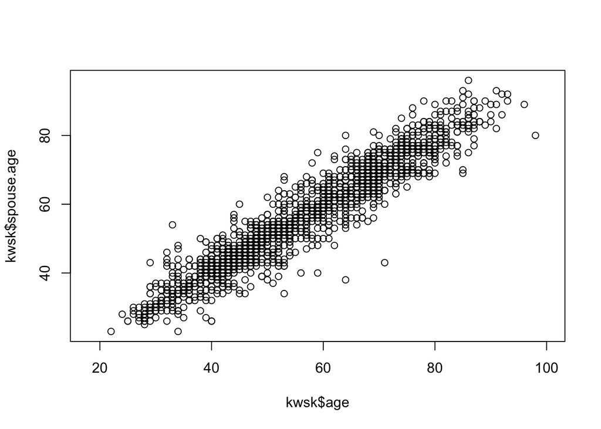

```r
plot(kwsk$age, kwsk$spouse.age)
```

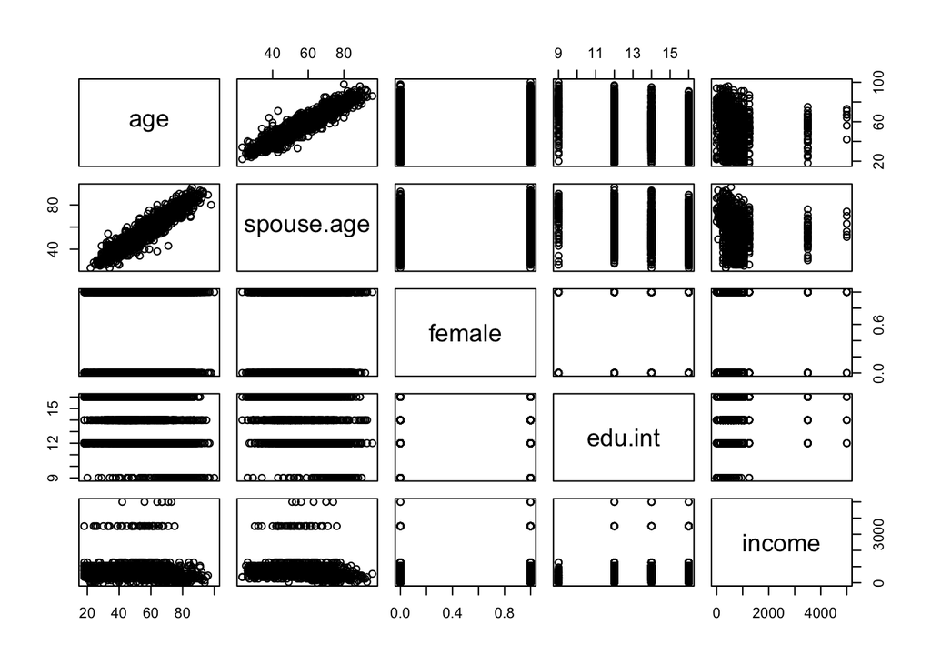

```r
kwsk %>% select(age, spouse.age, female, edu.int, income) %>%
  pairs()
```

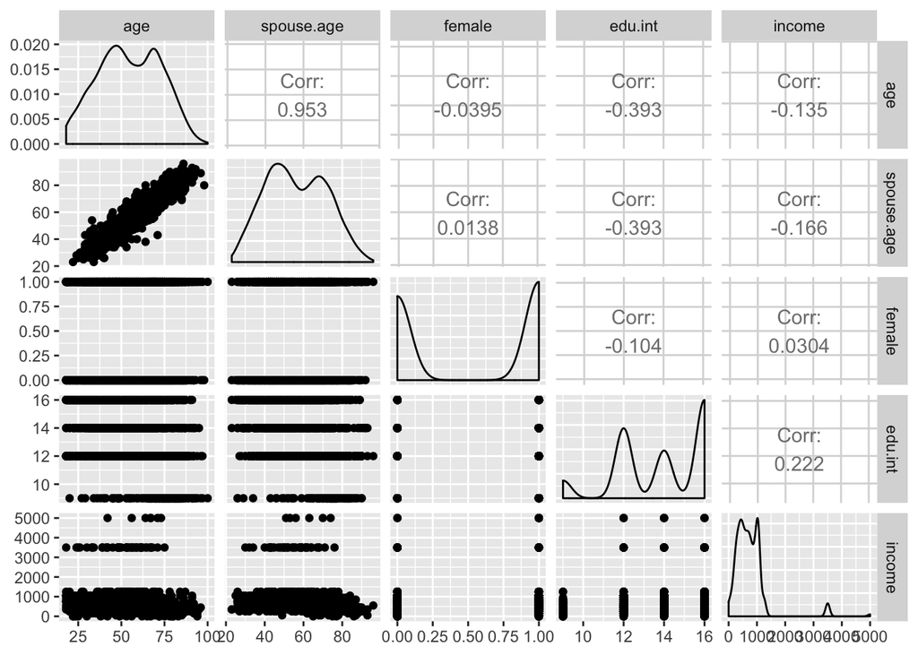

```r
kwsk %>% select(age, spouse.age, female, edu.int, income) %>%
  ggpairs()
```

## 順序尺度の扱い

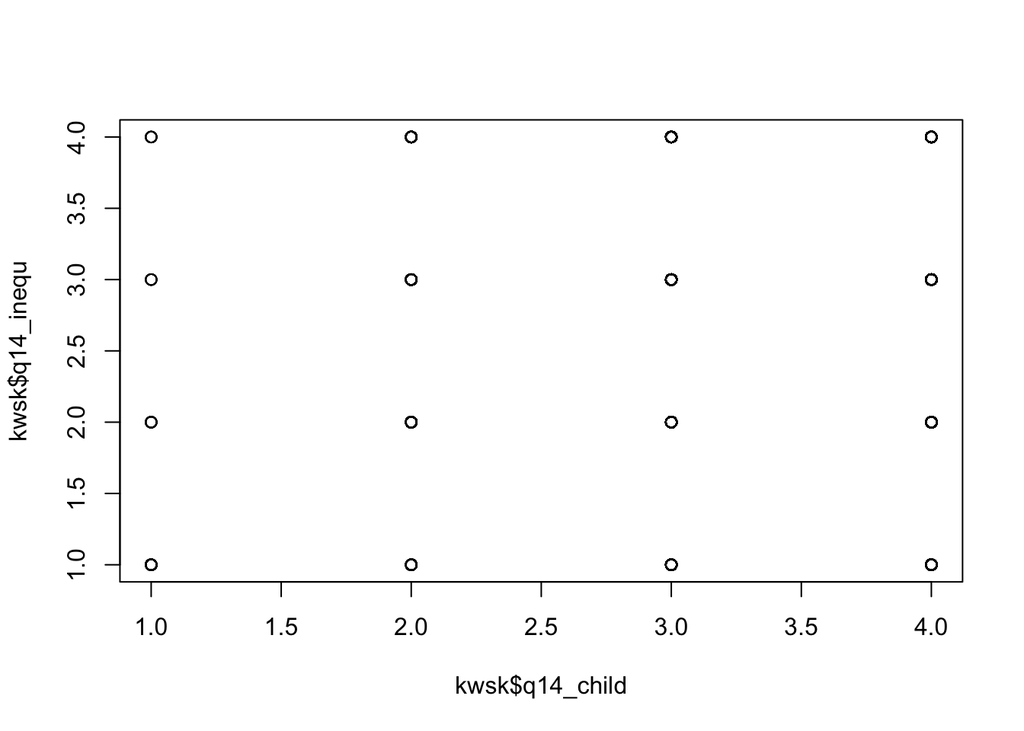

```r
plot(kwsk$q14_child, kwsk$q14_inequ) # 意味無し
```

### 1変数の視覚化

リカート尺度をまずは1変数ずつ視覚化します。 自分で分析するときこういったものを使うことはあまりないと思われますが、 調査協力者のための調査報告書などを書くときは結構便利です。

まずデータ`kwsk`から関心のある変数をさらに取り出し、それにラベルを付け、`kwsk.factors`に格納します。 ラベルに含まれてる`\n`は「エスケープシーケンス」と呼ばれるものの一つで、改行を指示するものです。

```r
kwsk.factors <- kwsk %>% select(q14_med, q14_housing, q14_jobless, q14_inequ, q14_child, q14_elderly, q14_disabled) %>%
  mutate_all(list(~factor(., level = c(1,2,3,4),
                             label = c("明らかに \n 政府責任ではない", "どちらかといえば \n 政府責任ではない",
                                       "どちらかといえば \n 政府責任", "明らかに \n 政府責任"))))

summary(kwsk.factors)
```

```
##                                 q14_med
##  明らかに \n 政府責任ではない        :  62
##  どちらかといえば \n 政府責任ではない: 332
##  どちらかといえば \n 政府責任        :1243
##  明らかに \n 政府責任                : 697
##  NA's                                : 123
##                               q14_housing
##  明らかに \n 政府責任ではない        :244
##  どちらかといえば \n 政府責任ではない:969
##  どちらかといえば \n 政府責任        :857
##  明らかに \n 政府責任                :253
##  NA's                                :134
##                               q14_jobless
##  明らかに \n 政府責任ではない        : 164
##  どちらかといえば \n 政府責任ではない: 824
##  どちらかといえば \n 政府責任        :1051
##  明らかに \n 政府責任                : 290
##  NA's                                : 128
##                                q14_inequ
##  明らかに \n 政府責任ではない        :237
##  どちらかといえば \n 政府責任ではない:695
##  どちらかといえば \n 政府責任        :815
##  明らかに \n 政府責任                :592
##  NA's                                :118
##                                q14_child
##  明らかに \n 政府責任ではない        :  41
##  どちらかといえば \n 政府責任ではない: 244
##  どちらかといえば \n 政府責任        :1173
##  明らかに \n 政府責任                : 882
##  NA's                                : 117
##                               q14_elderly
##  明らかに \n 政府責任ではない        :  39
##  どちらかといえば \n 政府責任ではない: 200
##  どちらかといえば \n 政府責任        :1216
##  明らかに \n 政府責任                : 895
##  NA's                                : 107
##                               q14_disabled
##  明らかに \n 政府責任ではない        :  31
##  どちらかといえば \n 政府責任ではない: 162
##  どちらかといえば \n 政府責任        :1188
##  明らかに \n 政府責任                : 971
##  NA's                                : 105
```

`likert`パッケージを用いたプロットを書きます。そのためには、以上でfactor型に変換してラベルをつけたものを `likert()`でさらに変換し格納しておく必要があります。

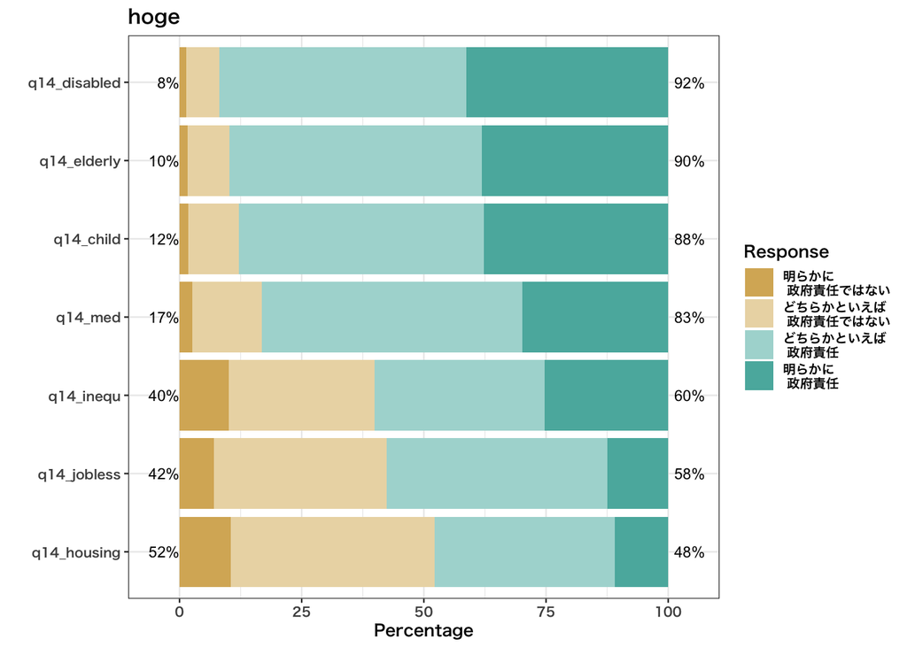

```r
lik <- likert(kwsk.factors)

plot(lik, type = "bar", centered = FALSE) +
  ggtitle("hoge") +
  theme_bw(base_family = "HiraKakuProN-W6",  base_size = 9)
```

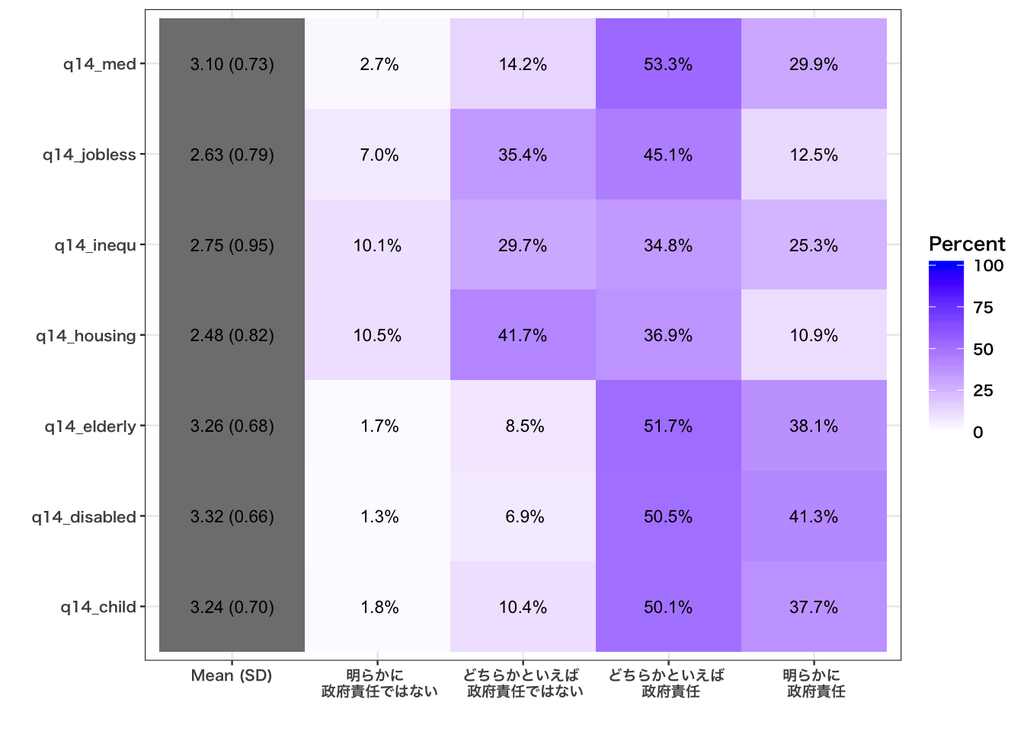

```r
# Windows ユーザーの場合、HiraKakuProN-W6 を Meiryo や Osaka などにすること。

plot(lik,
     type="heat",
     low.color = "white",
     high.color = "blue",
     text.color = "black",
     text.size = 3,
     wrap = 50) +
  theme_bw(base_family = "HiraKakuProN-W6",  base_size = 9)
```

`likert`パッケージではなく、`sjPlot`パッケージで書くことも可能です。 この場合、factor型に変換したデータフレームをそのまま使います。 `show.prc.sign = TRUE`などの各オプションが何を意味するのかは、`?plot_likert`命令で確認してみてください。

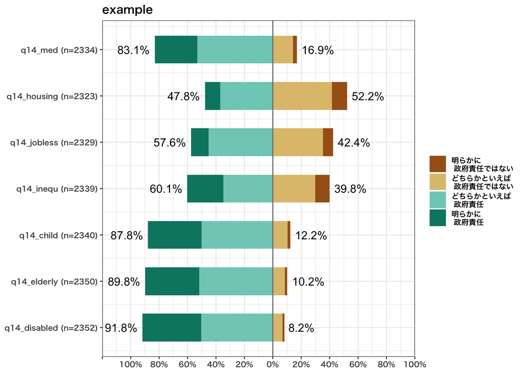

```r
plot_likert(
  kwsk.factors,
  title = "example",
  grid.range = c(1.2, 1,2),
  expand.grid = FALSE,
  values = "sum.outside",
  show.prc.sign = TRUE) +
  theme_bw(base_family = "HiraKakuProN-W6", base_size = 9)
```

### 2つの順序尺度の関係の視覚化

#### クロステーブルから

2つ以上のカテゴリカル変数の関係を見るには、第2回の講義で扱ったクロス表を用いるのが普通です。

```r
##### 1. R baseによるクロス表
xt <- with(kwsk, table(q14_child, q14_inequ), useNA = "ifany")
round(prop.table(xt), 3)
```

```
##          q14_inequ
## q14_child     1     2     3     4
##         1 0.011 0.003 0.002 0.002
##         2 0.013 0.044 0.029 0.019
##         3 0.041 0.166 0.200 0.093
##         4 0.035 0.086 0.117 0.139
```

```r
addmargins(xt)
```

```
##          q14_inequ
## q14_child    1    2    3    4  Sum
##       1     25    7    4    5   41
##       2     31  101   67   43  242
##       3     96  385  464  217 1162
##       4     82  200  271  323  876
##       Sum  234  693  806  588 2321
```

```r
##### 2. R base (stats) によるクロス表
xtabs(~ q14_child + q14_inequ, data = kwsk)
```

```
##          q14_inequ
## q14_child   1   2   3   4
##         1  25   7   4   5
##         2  31 101  67  43
##         3  96 385 464 217
##         4  82 200 271 323
```

```r
##### 3. gmodels パッケージによるクロス表とχ二乗検定
CrossTable(kwsk$q14_child, kwsk$q14_inequ, prop.chisq = F, chisq = T)
```

```
##
##
##    Cell Contents
## |-------------------------|
## |                       N |
## |           N / Row Total |
## |           N / Col Total |
## |         N / Table Total |
## |-------------------------|
##
##
## Total Observations in Table:  2321
##
##
##                | kwsk$q14_inequ
## kwsk$q14_child |         1 |         2 |         3 |         4 | Row Total |
## ---------------|-----------|-----------|-----------|-----------|-----------|
##              1 |        25 |         7 |         4 |         5 |        41 |
##                |     0.610 |     0.171 |     0.098 |     0.122 |     0.018 |
##                |     0.107 |     0.010 |     0.005 |     0.009 |           |
##                |     0.011 |     0.003 |     0.002 |     0.002 |           |
## ---------------|-----------|-----------|-----------|-----------|-----------|
##              2 |        31 |       101 |        67 |        43 |       242 |
##                |     0.128 |     0.417 |     0.277 |     0.178 |     0.104 |
##                |     0.132 |     0.146 |     0.083 |     0.073 |           |
##                |     0.013 |     0.044 |     0.029 |     0.019 |           |
## ---------------|-----------|-----------|-----------|-----------|-----------|
##              3 |        96 |       385 |       464 |       217 |      1162 |
##                |     0.083 |     0.331 |     0.399 |     0.187 |     0.501 |
##                |     0.410 |     0.556 |     0.576 |     0.369 |           |
##                |     0.041 |     0.166 |     0.200 |     0.093 |           |
## ---------------|-----------|-----------|-----------|-----------|-----------|
##              4 |        82 |       200 |       271 |       323 |       876 |
##                |     0.094 |     0.228 |     0.309 |     0.369 |     0.377 |
##                |     0.350 |     0.289 |     0.336 |     0.549 |           |
##                |     0.035 |     0.086 |     0.117 |     0.139 |           |
## ---------------|-----------|-----------|-----------|-----------|-----------|
##   Column Total |       234 |       693 |       806 |       588 |      2321 |
##                |     0.101 |     0.299 |     0.347 |     0.253 |           |
## ---------------|-----------|-----------|-----------|-----------|-----------|
##
##
## Statistics for All Table Factors
##
##
## Pearson's Chi-squared test
## ------------------------------------------------------------
## Chi^2 =  241.8703     d.f. =  9     p =  5.181562e-47
##
##
##
```

ただし、量が膨大になると数字だけを追うのは難しくなるので、場合によっては視覚化が必要になります。

#### Jittered Plot

`jitter()`は元の値にランダムなノイズを加えます。 見た目がいいとはとても言えませんが、だいたいどこに値が集中しているかは分かります。

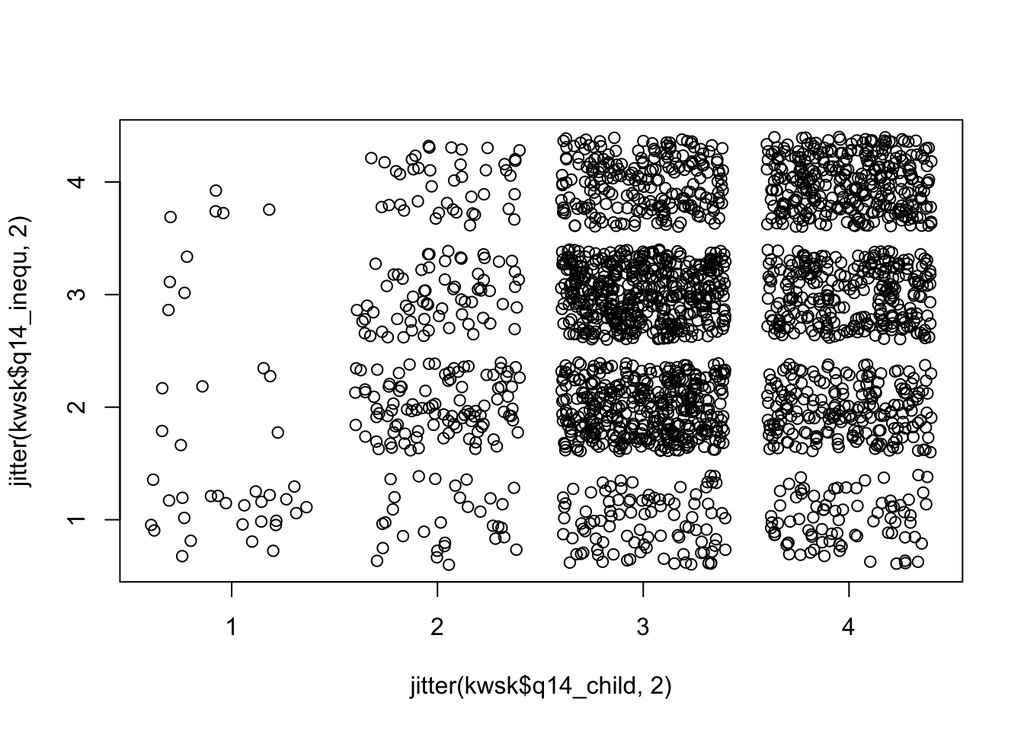

```r
#### Jittered Plot
plot(jitter(kwsk$q14_child, 2), jitter(kwsk$q14_inequ, 2))
```

jittered plotの他にも様々な方法がありますが、ここではballoonプロットを紹介します。

#### Balloon Plot

ここでは`ggpubr`パッケージと`ggballoonplot()`を用います。 2つの変数を選び、`table()`にしたものを`data.frame()`でデータフレーム形式にしたうえで、`ggballoonplot()`に読み込ませます。

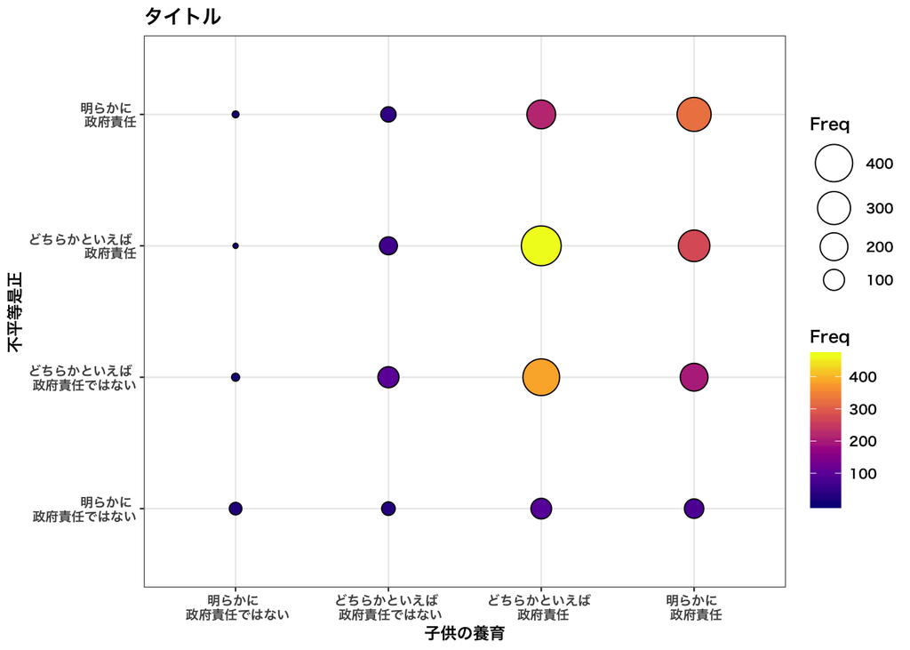

```r
#### Balloon Plot
ggballoon <- data.frame(table(child = kwsk.factors$q14_child,
                              inequ = kwsk.factors$q14_inequ))

ggballoonplot(ggballoon, x = "child", y = "inequ",
              fill = "Freq",
              ggtheme = theme_bw()) +
              ggtitle("タイトル") +
              xlab("子供の養育") +
              ylab("不平等是正") +
              scale_fill_viridis_c(option = "C") +
              theme_bw(base_family = "HiraKakuProN-W6", base_size = 9)
```

## 分散・共分散・ピアソン相関係数

### 分散・共分散・ピアソン相関係数を計算してみる

以下では、共分散と標準偏差、ピアソン相関係数をいちいち計算して求めてみます。

相関係数の一般的な計算式はデータに欠損がないことを前提としていますが、 実際のデータには欠損が入ってるxとyのペアが多く、その欠損値をどう処理するかによって計算方法が少しずつ変わってきます。 ここでは欠損値（NA）をすべて取り除いたケースのみで構成されたデータフレームをあえて作ることで、 手計算でも値が求まるようにします。

興味のある`age`と`spouse.age`で、両方にNAを含まないケースの数は`psych`パッケージの`pairwiseCount()`で簡単に数えられます。

```r
pairwiseCount(kwsk$age, kwsk$spouse.age) # kwskで、NAを含むペアを除くと n = 1640
```

```
##      [,1]
## [1,] 1640
```

`kwsk`から`age`と`spouse.age`を選びだし、その変数において一個でもNAが含まれているケースをすべて削除（listwise deletion）し、欠損値のないデータフレーム（`kwsk.ages.complete`）を作ります。

```r
kwsk.ages.complete <- kwsk %>%
  select(age, spouse.age) %>% na.omit
```

処理前と処理後のデータのケース数を比較すると、以下のようになります。

```r
nrow(kwsk) # 元のデータにはケースが2457個（行）だったが、
```

```
## [1] 2457
```

```r
nrow(kwsk.ages.complete) # 削除後は1640ケースのみになっている。これらのケースは欠損値を一つも含まない。
```

```
## [1] 1640
```

```r
n <- 1640 # pairwiseCount()で求めた値と同じ
```

式に沿って、不偏共分散と不偏標準偏差を求めます。

$$s_{x y} = \frac{1}{n-1} \sum_{i=1}^{n}\left(x_{i}-\bar{x}\right)\left(y_{i}-\bar{y}\right)$$

$$s_{x}=\sqrt{\frac{1}{n-1} \sum_{i=1}^{n}\left(x_{i}-\bar{x}\right)^{2}}$$

```r
# 不偏共分散 s_xy
s_xy <- (1/(n - 1))*sum((kwsk.ages.complete$age - mean(kwsk.ages.complete$age))*
               (kwsk.ages.complete$spouse.age - mean(kwsk.ages.complete$spouse.age))); s_xy
```

```
## [1] 227.4152
```

```r
# 不偏標準偏差 s_xとs_y
s_x <- sqrt((1/(n - 1))*sum((kwsk.ages.complete$age - mean(kwsk.ages.complete$age))^2)); s_x
```

```
## [1] 15.49231
```

```r
s_y <- sqrt((1/(n - 1))*sum((kwsk.ages.complete$spouse.age - mean(kwsk.ages.complete$spouse.age))^2)); s_y
```

```
## [1] 15.40923
```

求めた値は、共分散と標準偏差を求める命令である`cov()`, `sd()`で求めた値と一致します。

```r
cov(kwsk.ages.complete$age, kwsk.ages.complete$spouse.age)
```

```
## [1] 227.4152
```

```r
sd(kwsk.ages.complete$age)
```

```
## [1] 15.49231
```

```r
sd(kwsk.ages.complete$spouse.age)
```

```
## [1] 15.40923
```

求めた値で、相関係数を計算します。

$$r=\frac{s_{x y}}{\sqrt{s_{x}^{2} s_{y}^{2}}}=\frac{s_{x y}}{s_{x} s_{y}}$$

```r
(s_xy) / ((s_x)*(s_y))
```

```
## [1] 0.9526253
```

求めた値は、`cor()`で求めた相関係数と一致します。 なお、欠損処理する前の元のデータ`kwsk`から“NAのない組み合わせのみ”を用いて相関係数を求めた場合とも一致します。

```r
cor(kwsk.ages.complete$age, kwsk.ages.complete$spouse.age)
```

```
## [1] 0.9526253
```

```r
cor(kwsk$age, kwsk$spouse.age, use = "pairwise.complete.obs")
```

```
## [1] 0.9526253
```

## ピアソン相関係数の性質

### 単回帰との関係

```r
r <- cor(kwsk$spouse.age, kwsk$age, use = "pairwise.complete.obs")
r^2 # 0.907495
```

```
## [1] 0.907495
```

```r
lm <- lm(spouse.age ~ age, data = kwsk) # R-squared: 0.9075
summary(lm)
```

```
##
## Call:
## lm(formula = spouse.age ~ age, data = kwsk)
##
## Residuals:
##      Min       1Q   Median       3Q      Max
## -27.0799  -2.4451  -0.1295   2.6081  19.9258
##
## Coefficients:
##             Estimate Std. Error t value Pr(>|t|)
## (Intercept) 2.806181   0.436978   6.422 1.76e-10 ***
## age         0.947517   0.007475 126.764  < 2e-16 ***
## ---
## Signif. codes:  0 '***' 0.001 '**' 0.01 '*' 0.05 '.' 0.1 ' ' 1
##
## Residual standard error: 4.688 on 1638 degrees of freedom
##   (817 observations deleted due to missingness)
## Multiple R-squared:  0.9075, Adjusted R-squared:  0.9074
## F-statistic: 1.607e+04 on 1 and 1638 DF,  p-value: < 2.2e-16
```

```r
cor(lm$model[, 'spouse.age'], lm$fitted.values, use = "pairwise.complete.obs")^2
```

```
## [1] 0.907495
```

```r
summary(lm) # Y hat（推定されたY）とYのピアソン相関係数の二乗はR^2に一致する。
```

```
##
## Call:
## lm(formula = spouse.age ~ age, data = kwsk)
##
## Residuals:
##      Min       1Q   Median       3Q      Max
## -27.0799  -2.4451  -0.1295   2.6081  19.9258
##
## Coefficients:
##             Estimate Std. Error t value Pr(>|t|)
## (Intercept) 2.806181   0.436978   6.422 1.76e-10 ***
## age         0.947517   0.007475 126.764  < 2e-16 ***
## ---
## Signif. codes:  0 '***' 0.001 '**' 0.01 '*' 0.05 '.' 0.1 ' ' 1
##
## Residual standard error: 4.688 on 1638 degrees of freedom
##   (817 observations deleted due to missingness)
## Multiple R-squared:  0.9075, Adjusted R-squared:  0.9074
## F-statistic: 1.607e+04 on 1 and 1638 DF,  p-value: < 2.2e-16
```